# Covid-19 study

Kevin Juandi

2024-03-22

# Installing Libraries

```r
#install.packages("tidyverse")
#install.packages("lubridate")
#install.packages("ggplot2")
#install.packages("repr")
```

# Loading Libraries

```r
knitr::opts_chunk$set(echo = FALSE)
library(tidyverse, warn.conflicts = FALSE)
```

```r
library(lubridate, warn.conflicts = FALSE)
library(ggplot2, warn.conflicts = FALSE)
library(repr, warn.conflicts = FALSE)
options(repr.plot.width=10, repr.plot.height=8)
options(dplyr.summarise.inform = FALSE)
options(warn = -1)
```

# Loading the Data

Data Location: https://github.com/CSSEGISandData/COVID-19/tree/master/csse_covid_19_data/csse_covid_19_time_series

This data is the list of COVID-19 cases by country and province. I will use three files consisting of data for confirmed cases, deaths, and recoveries.

```r
death_global_data =
  read.csv(file = paste(
    'https://github.com/CSSEGISandData/COVID-19',
    'raw/master/csse_covid_19_data/csse_covid_19_time_series',
    'time_series_covid19_deaths_global.csv',
    sep = '/'))
confirmed_global_data =
  read.csv(file = paste(
    'https://github.com/CSSEGISandData/COVID-19',
    'raw/master/csse_covid_19_data/csse_covid_19_time_series',
    'time_series_covid19_confirmed_global.csv',
    sep = '/'
  ))
recovered_global_data =
  read.csv(file = paste(
    'https://github.com/CSSEGISandData/COVID-19',
    'raw/master/csse_covid_19_data/csse_covid_19_time_series',
    'time_series_covid19_recovered_global.csv',
    sep = '/'
  ))
```

# Preprocessing the data

This will take pretty long time due to the size of the data.

```r
tidy_data <- function(data) {
  result <- data %>%
    pivot_longer(cols = -c(`Province.State`, `Country.Region`, Lat, Long),
                 names_to = 'Date',
                 values_to = 'Cases') %>%
    select(-c(Lat, Long)) %>%
    mutate(Date = mdy(substring(Date, 2, length(Date)))) %>%
    group_by(Date) %>%
    summarise(
      Cases = sum(Cases),
    )
}

death_global_data_tidy <- tidy_data(death_global_data) %>%
  mutate(Deaths = Cases) %>%
  select(-Cases)
confirmed_global_data_tidy <- tidy_data(confirmed_global_data) %>%
  mutate(Confirmed = Cases) %>%
  select(-Cases)
recovered_global_data_tidy <- tidy_data(recovered_global_data) %>%
  mutate(Recovered = Cases) %>%
  select(-Cases)

global <- death_global_data_tidy %>%
  full_join(confirmed_global_data_tidy, by = 'Date') %>%
  full_join(recovered_global_data_tidy, by = 'Date')
```

Here I’ve converted the date columns to rows and then grouped by date. I’ve also added a column for the number of cases.

Three datasets were joined together to create a single dataset.

```r
head(global, 10)
```

```
## # A tibble: 10 × 4
##    Date       Deaths Confirmed Recovered
##    <date>      <int>     <int>     <int>
##  1 2020-01-22     17       557        30
##  2 2020-01-23     18       657        32
##  3 2020-01-24     26       944        39
##  4 2020-01-25     42      1437        42
##  5 2020-01-26     56      2120        56
##  6 2020-01-27     82      2929        65
##  7 2020-01-28    131      5580       108
##  8 2020-01-29    133      6169       127
##  9 2020-01-30    172      8237       145
## 10 2020-01-31    214      9927       225
```

# Visualization of data

## Numbers of cases

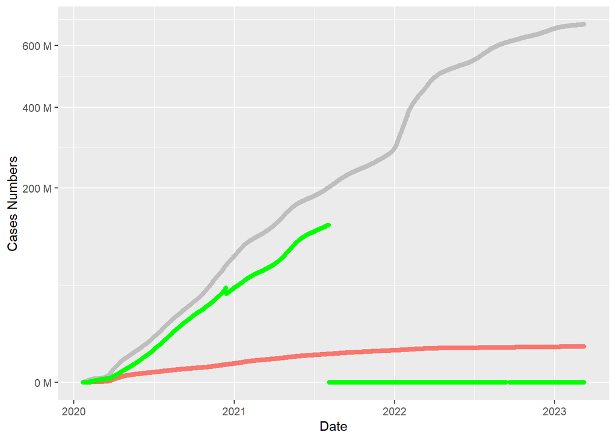

```r
global %>%
  ggplot() +
  ylab("Cases Numbers") +
  theme(legend.position = "none") +
  scale_y_sqrt(labels = scales::unit_format(unit = "M", scale = 1e-6)) +
  geom_point(aes(Date, Deaths, colour = 'Red')) +
  geom_point(aes(Date, Confirmed), colour = 'Gray') +
  geom_point(aes(Date, Recovered), colour = 'Green')
```

Red - deaths, Gray - confirmed, Green - recovered.

Here we can see how the number of cases change over time. Unfortunately, recovered cases data is missing after the mid of 2021.

## Numbers for first 6 month

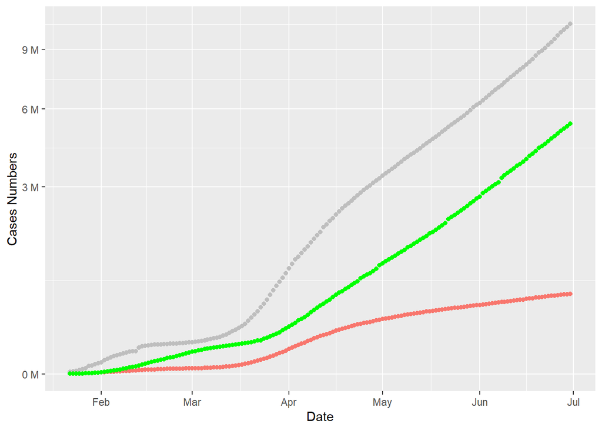

```r
global %>%
  filter(Date < '2020-07-01') %>%
  ggplot() +
  ylab("Cases Numbers") +
  theme(legend.position = "none") +
  scale_y_sqrt(labels = scales::unit_format(unit = "M", scale = 1e-6)) +
  geom_point(aes(Date, Deaths, colour = 'Red')) +
  geom_point(aes(Date, Confirmed), colour = 'Grey') +
  geom_point(aes(Date, Recovered), colour = 'Green')
```

This graph shows first 6 month of pandemic.

## The trends for cases numbers

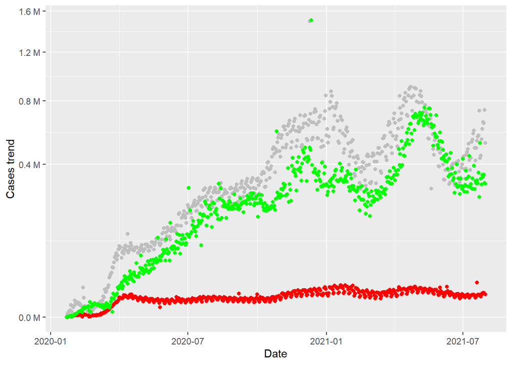

```r
global %>%
  filter(Date < '2021-08-01') %>%
  mutate(trendDeaths = ifelse(is.na(lag(Deaths)), 0, Deaths - lag(Deaths))) %>%
  mutate(trendConfirmed = ifelse(is.na(lag(Confirmed)), 0, Confirmed - lag(Confirmed))) %>%
  mutate(trendRecovered = ifelse(is.na(lag(Recovered)), 0, Recovered - lag(Recovered))) %>%
  ggplot() +
  theme(legend.position = "none") +
  ylab("Cases trend") +
  scale_y_sqrt(labels = scales::unit_format(unit = "M", scale = 1e-6)) +
  geom_point(aes(Date, trendDeaths), colour = 'Red', na.rm = TRUE) +
  geom_point(aes(Date, trendConfirmed), colour = 'Gray', na.rm = TRUE) +
  geom_point(aes(Date, trendRecovered), colour = 'Green', na.rm = TRUE)
```

Red - deaths trend, gray - confirmed trend, green - recovered trend.

This graph show the trend of new cases over time until our last recovered data. Let’s take a look of the entire data for confirmed cases and confirmed deaths

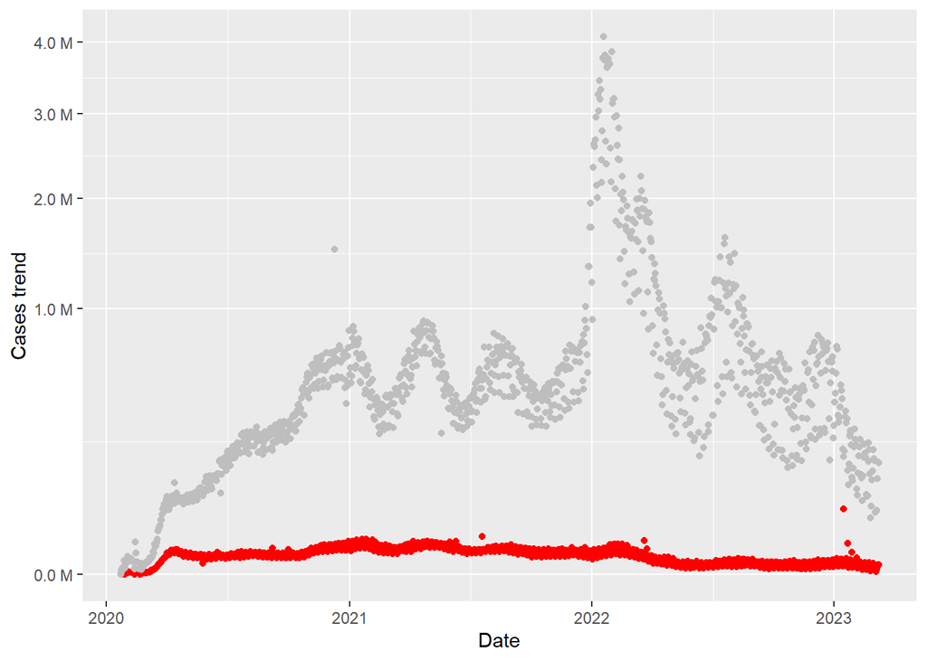

```r
global %>%
  mutate(trendDeaths = ifelse(is.na(lag(Deaths)), 0, Deaths - lag(Deaths))) %>%
  mutate(trendConfirmed = ifelse(is.na(lag(Confirmed)), 0, Confirmed - lag(Confirmed))) %>%
  ggplot() +
  theme(legend.position = "none") +
  ylab("Cases trend") +
  scale_y_sqrt(labels = scales::unit_format(unit = "M", scale = 1e-6)) +
  geom_point(aes(Date, trendDeaths), colour = 'Red', na.rm = TRUE) +
  geom_point(aes(Date, trendConfirmed), colour = 'Gray', na.rm = TRUE)
```

# Modeling covid-19 deaths trend

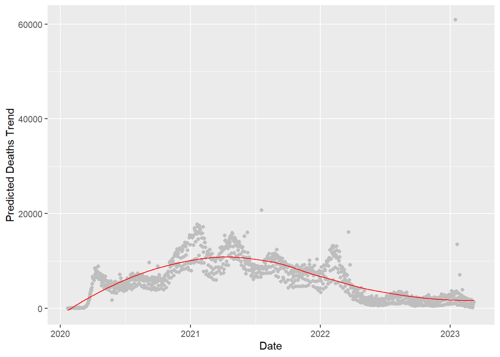

```r
globalDeathsTrend <- global %>%
  mutate(trendDeaths = ifelse(is.na(lag(Deaths)), Deaths, Deaths - lag(Deaths)))
mod <- loess(trendDeaths ~ as.numeric(Date), globalDeathsTrend)
globalDeathsTrend <- globalDeathsTrend %>%
  mutate(predictedDeathsTrend = predict(mod))

globalDeathsTrend %>%
  ggplot() +
  ylab("Predicted Deaths Trend") +
  theme(legend.position = "none") +
  geom_point(aes(Date, trendDeaths), colour = 'Gray') +
  geom_line(aes(Date, predictedDeathsTrend), colour = 'Red')
```

Red line - deaths trend from the model, gray points - deaths trend from the data.

# Conclusion

# Biases identified

It is unclear if the data collection in different countries followed the same rules/standards.